# Introduction

This analysis is for twitter account WeRateDogs data wrangling project. I designed 3 sections of plots.

- First section is favorite and retweet by timestamp
- Second section is favorite count v retweet count and colored by rating ratio
- Third section favorite count v retweet count and colored by text length with more than 10 words

# Analysis

```python
from PIL import Image
```

```python
plt1=Image.open('Favorite Counts by Timestamp.png')
plt2=Image.open('Retweet Counts by Timestamp.png')
plt3=Image.open('Retweets v Favorite Counts Colored by Rating Ratio.png')
plt4=Image.open('Retweets v Favorite Counts Colored by Text Length with 10 or More Words.png')
```

### Section 1

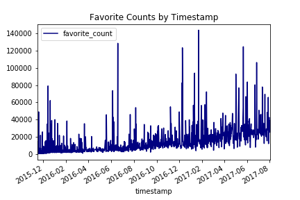

```python
plt1
```

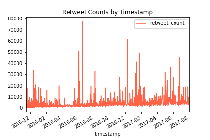

```python
plt2
```

We can see that the trend of favorite and retweet counts are increasing overtime. The trend is most conspicuous at “Favorite Counts by Timestamp” plot. There are some popular or trending tweets that received plenty of favorites and retweet. The peaks of favorite and retweet are consistent at same timestamp, which is reasonable. This occurs more often in the recent time. We can assume that the account become more famous and popular overtime.

### Section 2

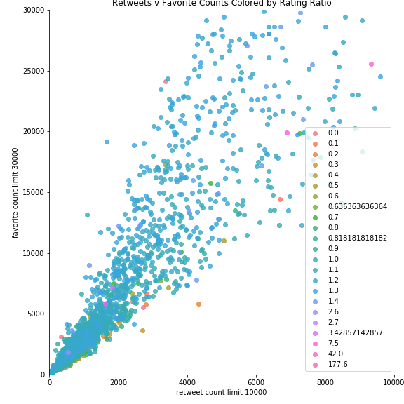

```python
plt3
```

We can see that most of the ratings are between 1 to 1.4, meaning the numerator is higher than the denominator (10) usually. The rating ratio among low retweet and low favorites is the same among high retweet and high favorites. We can see that the rating ratio does not affect retweet and favorites at all. We can draw that, evidently, WeRateDog does not use the rating to get high favorites and retweets, but use this method to draw more popularity.

### Section 3

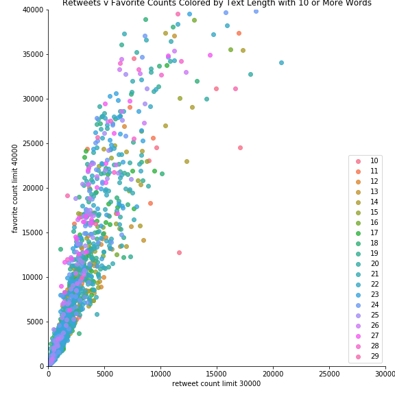

```python
plt4
```

We can see that with the same retweet counts (x), text with more words has a higher favorite counts (y). This might be more text make people enjoy more about the pictures/ tweets, causing them to have emotional fluctuation, thus mark the tweet as favorite, so more words help the tweet receive more favorite counts.

# Conclusion

From the last three sections, we see that:

- favorite counts are consistent with retweet counts and there is an upward trend over time.
- Rating does not matter in this account, just a way to attract more viewers.
- With same retweet amount , more text creates more favorite.